# Introducing the pct package

Obtaining and reproducing data from the Propensity to Cycle Tool (PCT)

Robin Lovelace and Layik Hama

2022-11-14

## Introduction

Since work on the package began in 2015, for example during the ODI Leeds Hack my Route [hackathon](https://datamillnorth.org/community/blog/hack-my-route-live-blog/) (see [an early prototype of the tool here](https://twitter.com/robinlovelace/status/611979463803432960)), the features and demand for the PCT have evolved substantially. In early 2019, for example, the [School travel layer](https://blog.pct.bike/2019/03/18/propensity-to-cycle-to-school-layer-deployed/) was added to the main PCT site to provide evidence nationwide on the potential benefits of scenarios of cycling uptake, and where safe routes to school should be prioritised<sup>3</sup>. In fact, a major aim of the PCT was to enable people to extend the tool<sup>2</sup>:

> We envision stakeholders in local government modifying scenarios for their own purposes, and that academics in relevant fields may add new features and develop new use cases of the PCT.

Motivated by this vision of adaptable transport planning tools, this introductory vignette demonstrates how the package works with an example from the [Isle of Wight](https://en.wikipedia.org/wiki/Isle_of_Wight), an island just off the southern coast of Britain, with a population of ~140,000 people. Before demonstrating some of the package’s key functions, it’s worth providing a little context.

## Why this package?

The Propensity to Cycle Tool was commissioned by the UK’s Department for Transport to help planners and others prioritise investment and policies to get people cycling, as outlined in the Government report [National propensity to cycle: full report with annexes](https://www.gov.uk/government/publications/national-propensity-to-cycle-first-phase-development-study)<sup>4</sup>. However, the academic team leading the project had a wider sub-aim: of making transport evidence more accessible, encouraging evidence-based transport policies, and encouraging a more democratic transport planning process, and that means open transport data and open source transport modelling tools<sup>2</sup>.

The code base underlying the PCT is publicly available (see [github.com/npct](https://github.com/npct/)). However, the code hosted there is not easy to run or reproduce, which is where this package comes in: it provides quick access to the data underlying the PCT and enables some of the key results to be reproduced quickly. It was developed primarily for educational purposes (including for upcoming PCT training courses) but it may be useful for people to build on the the methods, for example to create a scenario of cycling uptake in their town/city/region.

In summary, if you want to know how PCT works, be able to reproduce some of its results, and build scenarios of cycling uptake to inform transport policies enabling cycling in cities worldwide, this package is for you!

## Installation

You can install the development version of the package as follows:

```r
remotes::install_github("ITSLeeds/pct")
```

Load the package as follows:

```r
library(pct)
```

We will also use the following packages in this tutorial:

```r
library(sf)
library(dplyr)
library(stplanr)
library(leaflet)
library(ggplot2)
library(pbapply)
```

# Get PCT data

From feedback, we hear that the use of the data is critical in decision making. Therefore, one area where the package could be useful is making the data “easily” available to be processed.

To download the data within www.pct.bike, we have added a suite of functions:

- `get_pct()`
- `get_pct_rnet()`
- `get_pct_zones()`
- `get_pct_lines()`
- `get_pct_centroids()`
- `get_pct_routes_fast()`
- `get_pct_routes_quiet()`

```r
wight_centroids = get_pct_centroids(region = "isle-of-wight", geography = "msoa")
wight_zones = get_pct_zones(region = "isle-of-wight", geography = "msoa")
```

Let’s verify that the data gave us what we would expect to see:

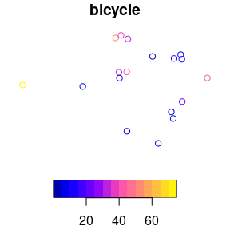

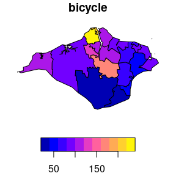

```r
plot(wight_centroids[, "bicycle"])
plot(wight_zones[, "bicycle"])
```

```r
wight_lines_pct = get_pct_lines(region = "isle-of-wight", geography = "msoa")
```

The rest of the `get_pct_` functions are similar to the above two examples and download data from www.pct.bike.

However, the base of these functions is `get_pct()`, which takes the following arguments:

- `base_url = "https://github.com/npct/pct-outputs-regional-R/raw/master"`: just in case if you wanted to download the data from a similar server
- `purpose = "commute"`: soon there will be “schools” and maybe other modes, but currently commute is the only option.
- `geography = "msoa"`: MSOA or LSOA
- `region = NULL`: regions within `pct::pct_regions`
- `layer = NULL`: one of `z` (zones), `c` (centroids), `l` (desire lines), `rf` (routes fast), `rq` (routes quiet) or `rnet`.
- even `extension = ".Rds"` as PCT data is available in various formats. For the purpose of this package we have made the default option of “Rds”.

# Comparing downloaded data with the PCT web app

To compare the downloaded data with data in the PCT web app, we will take a subset of the `wight_lines_pct` dataset. The top 30 travelled desire lines by number of commuters who use cycling as their main mode is taken in the following code chunk. The reason for selecting the top 30 will become apparent (the `wight_lines_30` object is provided in the PCT package):

```r
wight_lines_30 = wight_lines_pct %>%
  top_n(30, bicycle)
```

The resulting `wight_lines_pct` and `wight_lines_30` datasets are available in the package. We’ll use the smaller one for speed. Note: these contain many variables, three of which (the number of people cycling, driving and walking along the desire lines from the 2011 Census) are shown below for the Isle of Wight:

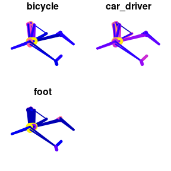

```r
lwd = wight_lines_30$all / mean(wight_lines_30$all) * 5
plot(wight_lines_30[c("bicycle", "car_driver", "foot")], lwd = lwd)
```

To provide another view of the data, focus on cycling, let’s create a leaflet map:

```r
pal = colorNumeric(palette = "RdYlBu", domain = wight_lines_30$bicycle)
leaflet(data = wight_lines_30) %>%
  addTiles() %>%
  addPolylines(weight = lwd,
               color = ~ pal(bicycle)) %>%
  addLegend(pal = pal, values = ~bicycle)
```

[interactive chart not shown]

There was a reason for selecting the top 30 lines: it mirrors the view of the desire lines available from the PCT web application for the island, available at www.pct.bike/m/?r=isle-of-wight (note that Straight Lines is selected from the Cycling Flows dropdown menu in the image below, and by default shows the top 30 flows by number of bicycle trips).

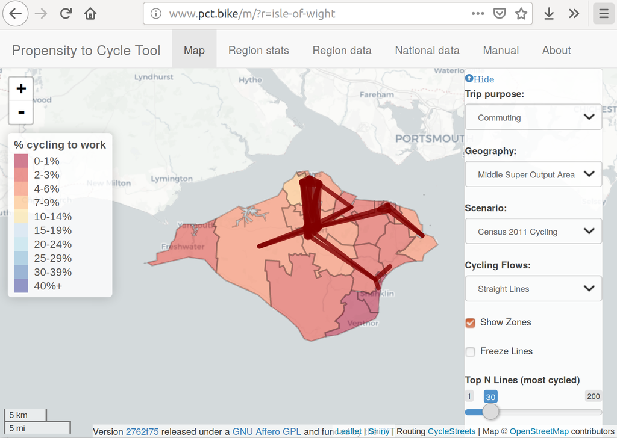

## Getting Census data

The previous section showed that data downloaded with `get_pct*()` functions *get* the results generated by the PCT. However, they do not *reproduce* the results generated by the PCT, starting from first principles and publicly available, official data. Underlying the PCT is origin-destination data from the 2011 Census. The MSOA-level data is open access, so we only provide access to this dataset. The following command gets the origin-destination data for the Isle of Wight:

```r
wight_od_all = get_od(region = "wight")
```

```r
summary(wight_od_all$geo_code1 %in% wight_centroids$geo_code)
```

```
#>    Mode    TRUE
#> logical    2851
```

```r
summary(wight_od_all$geo_code2 %in% wight_centroids$geo_code)
```

```
#>    Mode   FALSE    TRUE
#> logical    2527     324
```

Note that all the origin codes match the Isle of Wight centroid codes, but most of the destination zones do not. This is because many people on the island work outside the island. `get_od()` by default returns only OD pairs in which the commute trips originate from the `area` entered.

To make the dataset smaller and simpler, let’s subset it so it only contains OD pairs in which the origin *and* destination are in the island (the resulting `wight_od` data is provided in the package):

```r
wight_od = wight_od_all %>%
  filter(geo_code2 %in% wight_centroids$geo_code)
```

To convert the results to geographic desire lines, we can use the function `od2line()` from the `stplanr` package:

```r
wight_lines = od2line(wight_od, wight_centroids)
nrow(wight_lines)
```

```
#> [1] 324
```

```r
sum(wight_lines$all)
```

```
#> [1] 42139
```

```r
wight_lines_census = wight_lines %>%
  filter(geo_code1 != geo_code2)
nrow(wight_lines_census)
```

```
#> [1] 306
```

```r
sum(wight_lines_census$all)
```

```
#> [1] 32683
```

Another OD data processing step developed for the PCT was converting oneway lines into 2 way lines. This can be done as follows:

```r
wight_lines_census1 = od_oneway(
  wight_lines_census,
  attrib = c("all", "bicycle")
  )
nrow(wight_lines_census1) / nrow(wight_lines_census)
```

```
#> [1] 0.5
```

```r
sum(wight_lines_census1$all) / sum(wight_lines_census$all)
```

```
#> [1] 1
```

Note that the resulting lines contain 50% of the number of lines, but the same number of trips: this is because 2 separate lines between the same zones have been converted into 1 line representing the combined number of trips in both directions, for each OD pair. This step is not essential but it has a couple of advantages: it was used in the PCT to make the routing more computationally efficient (less work computing the same route twice); and it makes visualising the lines and routes simpler.

Now that the lines data contains data on 2 way trips between zones, we can estimate routes (note: the results on the PCT website contain estimated uptake levels from intrazonal flow) Visually, this involves converting the straight desire lines shown in the previous map into routes that can be cycled, as shown in the next code chunk. Note: this code does not run dynamically, because you need an [CycleStreets.net API key](https://www.cyclestreets.net/api/apply/) for this, and it takes some time:

```r
wight_routes_fast = route(
  l = wight_lines_census1,
  route_fun = cyclestreets::journey,
  plan = "fastest")
```

You can download these routes as follows:

```r
u = "https://github.com/ITSLeeds/pct/releases/download/0.5.0/wight_routes_fast.Rds"
wight_routes_fast = readRDS(url(u))
```

A sample of these is provided in the package as `wight_routes_30_cs`, which was generated as follows:

```r
wight_lines_census_30 = wight_lines_census1 %>%
  top_n(30, bicycle)
```

```r
wight_routes_30_cs = wight_routes_fast %>%
  group_by(geo_code1, geo_code2) %>%
  summarise(
    all = mean(all),
    bicycle = mean(bicycle),
    av_incline = weighted.mean(gradient_smooth, w = distances),
    length = sum(distances),
    time = sum(time)
    ) %>%
  ungroup() %>%
  top_n(30, bicycle)
```

A simple verification that we have the right desire lines matched to the routes involves plotting the Euclidean vs Route distance, e.g. as follows:

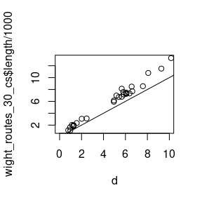

```r
d = as.numeric(st_length(wight_lines_census_30)) / 1000
plot(d, wight_routes_30_cs$length / 1000, xlim = c(0, 10))
abline(a = c(0, 1))
```

How well does that match the route distance data downloaded from the PCT?

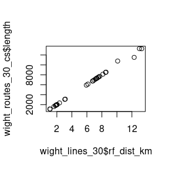

```r
plot(wight_lines_30$rf_dist_km, wight_routes_30_cs$length)
```

Almost perfectly for most of the routes. Differences can be explained by changes in infrastructure since the PCT results were first generated (these will be updated in the Propensity to Cycle Tool on-line data later in 2019).

We now have everything needed to estimate cycling uptake for each desire lines on the Isle of Wight (we’ll do the calculation on the top 30 by current cycling levels).

## Estimate cycling uptake

Functions named with `uptake_*()` estimate cycling uptake:

- `uptake_pct_godutch()`: generates the “GoDutch” scenario level of cycling based on a particular route’s hilliness percentage and length.
- `uptake_pct_govtarget()`: generates the UK government target again based on the hilliness and length parameters.

```r
pcycle_govtarget = uptake_pct_govtarget(
  distance = wight_routes_30_cs$length,
  gradient = wight_routes_30_cs$av_incline * 100
)
```

In terms of cycling uptake, the results are shown below:

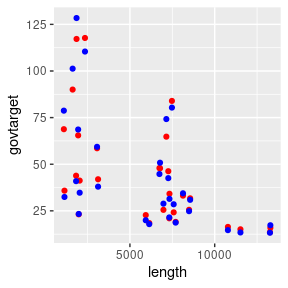

```r
wight_routes_30_cs$govtarget = wight_lines_census_30$bicycle +
  pcycle_govtarget * wight_lines_census_30$all
wight_routes_30_cs$govtarget_pct = wight_lines_30$govtarget_slc

ggplot(wight_routes_30_cs) +
  geom_point(aes(length, govtarget), colour = "red") +
  geom_point(aes(length, govtarget_pct), colour = "blue")
```

```r
cor(wight_routes_30_cs$govtarget, wight_routes_30_cs$govtarget_pct)
```

```
#> [1] 0.9886002
```

```r
wight_routes_30_ls = sf::st_cast(wight_routes_30_cs, "LINESTRING")
```

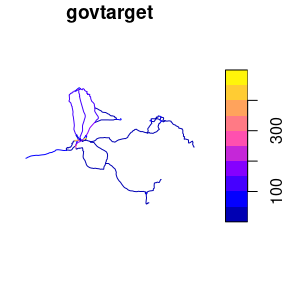

```r
rnet = overline(wight_routes_30_ls, "govtarget")
plot(rnet)
```

Running the same function for all routes in `wight_routes_fast`, generates the packaged data object `wight_rnet`, which was created as follows:

```r
wight_routes_fast_gt = wight_routes_fast %>%
  group_by(geo_code1, geo_code2) %>%
  mutate(
    govtarget = uptake_pct_govtarget(sum(distances), mean(gradient_smooth)) *
      (sum(all) + sum(bicycle))
  )
wight_routes_fast_gt = sf::st_cast(wight_routes_fast_gt, "LINESTRING")
wight_rnet = overline(wight_routes_fast_gt, "govtarget")
```

```r
pal = colorNumeric(palette = "RdYlBu", domain = wight_rnet$govtarget)
leaflet(data = wight_rnet) %>%
  addTiles() %>%
  addPolylines(color = ~ pal(govtarget)) %>%
  addLegend(pal = pal, values = ~govtarget)
```

[interactive chart not shown]

# References

1.

Department for Transport. *[Local Cycling and Walking Infrastructure Plans](https://assets.publishing.service.gov.uk/government/uploads/system/uploads/attachment_data/file/607016/cycling-walking-infrastructure-technical-guidance.pdf)*. (Department for Transport, 2017).

2.

Lovelace, R. *et al.* [The Propensity to Cycle Tool: An open source online system for sustainable transport planning](https://doi.org/10.5198/jtlu.2016.862). *Journal of Transport and Land Use* **10,** (2017).

3.

Goodman, A. *et al.* [Scenarios of cycling to school in England, and associated health and carbon impacts: Application of the ‘Propensity to Cycle Tool’](https://doi.org/10.1016/j.jth.2019.01.008). *Journal of Transport & Health* **12,** 263–278 (2019).

4.

Department for Transport. *[National Propensity to Cycle Tool Project: Full report with annexes](https://www.gov.uk/government/publications/national-propensity-to-cycle-first-phase-development-study)*. (Department for Transport, 2016).